# Clase 7: Modelos lineales Generalizados Mixtos

[figure not shown]

[Fitting Linear Mixed-Effects Models Using lme4](https://doi.org/10.18637/jss.v067.i01)

[Parsimoniously Fitting Large Multivariate Random Effects in glmmTMB](https://doi.org/10.18637/jss.v112.i01)

Literatura recomendada para compreder los modelos mixtos, [Harrison *et al*. 2018](https://doi.org/10.7717/peerj.4794)

### Introduccion

En estudios ecológicos y de conservación, es común que los datos presenten una estructura jerárquica o dependiente. Por ejemplo, se pueden tomar múltiples mediciones en los mismos sitios de muestreo, en diferentes momentos, o bien registrar varias observaciones dentro de unidades mayores como fincas, parcelas o paisajes. Este tipo de datos se conoce como diseños de medidas repetidas o estudios longitudinales, y viola el supuesto de independencia entre observaciones requerido por muchos modelos estadísticos tradicionales.

Los modelos mixtos surgen como una herramienta fundamental para abordar este problema, ya que permiten incorporar explícitamente esta estructura jerárquica mediante la inclusión de efectos fijos (variables de interés, como características del hábitat) y efectos aleatorios (fuentes de variación asociadas a unidades de muestreo, como sitio, finca o año). De esta forma, es posible modelar adecuadamente la dependencia en los datos y obtener inferencias más robustas y realistas.

#### Efectos fijos y efectos aleatorios

En estadística frecuentista existe una distinción fundamental al momento de modelar variables categóricas, basada en la diferencia entre efectos fijos y efectos aleatorios, propuesta originalmente por Churchill Eisenhart (1947).

Los efectos fijos son aquellas variables explicativas cuyo efecto queremos estimar directamente y que representan relaciones a nivel poblacional. Estos pueden ser tanto categóricos (por ejemplo, tipo de hábitat o tratamiento) como numéricos (por ejemplo, área basal, elevación o porcentaje de bosque). Cuando una variable se incluye como efecto fijo, lo que estamos estimando es un valor promedio que describe cómo cambia la variable respuesta en función de esa variable explicativa. En el caso de variables categóricas, esto implica comparar niveles específicos; mientras que, para variables numéricas, implica estimar una relación continua (por ejemplo, una pendiente). Un aspecto fundamental es que los efectos fijos representan relaciones que son de interés directo para el estudio, y sobre las cuales queremos hacer inferencia. Sin embargo, en el caso de variables categóricas, las conclusiones se limitan a los niveles incluidos en el análisis, ya que estos fueron definidos de manera intencional.

Por otro lado, tenemos los efectos aleatorios. Estos corresponden generalmente a variables categóricas cuyos niveles pueden considerarse como una muestra tomada al azar de una población mucho más grande de posibles niveles. Los efectos aleatorios representan la variabilidad entre grupos. Es decir, capturan cuánto se desvía cada grupo (por ejemplo, sitios, individuos o años) del promedio general de la variable respuesta, el cual está descrito por los efectos fijos. Para entenderlo con un ejemplo sencillo, supongamos que queremos evaluar si un medicamento tiene un efecto curativo sobre una enfermedad. Definimos una variable categórica con dos niveles: “medicamento” y “placebo”, la cual modelamos como un efecto fijo, ya que es el factor de interés principal. Sin embargo, sabemos que la genética de los individuos también puede influir tanto en la enfermedad como en la respuesta al tratamiento. Entonces, tomamos una muestra de individuos que pertenecen a distintos genotipos (por ejemplo, 17 genotipos diferentes, con varios individuos en cada uno). En este caso, comparar directamente los 17 genotipos no es el objetivo del estudio. Más bien, sabemos de antemano que el genotipo introduce variabilidad en la respuesta que queremos medir (el efecto del medicamento). Por eso, lo incluimos en el modelo como un efecto aleatorio. De esta forma, el genotipo actúa como una fuente de variación que necesitamos controlar, pero no interpretar directamente. En otras palabras, es una variable que influye en la respuesta, pero que no es el foco principal de la investigación.

#### Sintaxis en R para efectos aleatorios en modelos mixtos

Supongamos que S y T son variables categóricas incluidas como efectos aleatorios (por ejemplo, sitio o año), mientras que X y W son variables explicativas (numéricas o categóricas) incluidas como efectos fijos en el modelo. Las siguientes son algunas de las formas más comunes de especificar efectos aleatorios en R. Esta lista no es exhaustiva; existen otras combinaciones posibles como (1 | S) + (X | T) o (1 | S) + (0 + X | T).

| Notación | Significado de los efectos aleatorios |
| --- | --- |
| `(1 \| S)` | Interceptos aleatorios para cada nivel de **S**. |
| `(0 + X \| S)` | Pendientes aleatorias para **X** en cada nivel de **S**, sin intercepto aleatorio. Equivalente a `(-1 + X \| S)`. |
| `(1 + X \| S)` | Interceptos y pendientes aleatorias para **X** en cada nivel de **S**, permitiendo correlación entre ambos. |
| `(1 \| S) + (0 + X \| S)` | Interceptos y pendientes aleatorias para **X** en cada nivel de **S**, sin correlación entre ellos. |
| `(X \|\| S)` | Igual que `(1 + X \| S)`, pero forzando independencia (sin correlación) entre intercepto y pendiente. |
| `(X*W \| S)` | Interceptos y pendientes aleatorias para la interacción **X** * **W** dentro de cada nivel de **S**. |
| `(1 \| S) + (1 \| T)` | Interceptos aleatorios independientes (efectos cruzados) para **S** y **T**. |
| `(1 + X \| S/T)` | Efectos anidados: **T** dentro de **S**. Equivalente a `(1 + X \| S) + (1 + X \| S:T)`. |

En modelos mixtos, un intercepto aleatorio y una pendiente aleatoria representan dos formas distintas en que los grupos pueden diferir entre sí. Cuando usamos un modelo como (1 | Sitio), estamos permitiendo que cada sitio tenga su propio valor base de la variable respuesta, es decir, cada grupo comienza desde un nivel distinto, pero la relación con la variable explicativa (por ejemplo, el efecto de bosque sobre abundancia) se mantiene igual en todos los sitios; gráficamente, esto se vería como líneas paralelas con diferente altura. En cambio, cuando usamos una estructura como (Bosque | Sitio), estamos permitiendo que cada sitio tenga no solo su propio intercepto, sino también su propia pendiente, lo que implica que la relación entre la variable explicativa y la respuesta cambia entre sitios; en este caso, las líneas ya no son paralelas, sino que tienen distintas inclinaciones. En términos simples, el intercepto aleatorio cambia el punto de partida entre grupos, mientras que la pendiente aleatoria permite que cambie la intensidad o dirección del efecto de una variable entre esos grupos.

En los modelos mixtos, los efectos cruzados y los efectos anidados describen distintas formas en que se organizan los datos. Los efectos cruzados ocurren cuando dos factores (por ejemplo, sitio y año) se combinan de manera independiente, es decir, cada nivel de uno puede aparecer con varios niveles del otro (por ejemplo, los mismos sitios muestreados en múltiples años). En cambio, los efectos anidados se dan cuando los niveles de un factor están contenidos dentro de otro (por ejemplo, parcelas dentro de fincas), de modo que cada nivel del factor inferior pertenece únicamente a un nivel del factor superior. Por otro lado, la diferencia entre intercepto aleatorio y pendiente aleatoria radica en qué aspecto de la relación se permite variar entre grupos: un intercepto aleatorio implica que cada grupo tiene su propio valor base (su propia línea de partida), manteniendo la misma relación con la variable explicativa; mientras que una pendiente aleatoria permite que la relación entre la variable explicativa y la respuesta cambie entre grupos, es decir, que cada grupo tenga su propia pendiente o intensidad de efecto.

#### Ejercicio

Usaremos datos de [Akresh et al. 2009](https://doi.org/10.1525/cond.2009.080059), un estudio basado en un proyecto de captura con redes de niebla en aves en bosques ribereños y de tierras altas del norte de Michigan. En este trabajo se registró la presencia o ausencia de aves juveniles capturadas en redes en tres sitios de estudio, visitados en distintos días, donde cada sitio incluía tanto hábitat ribereño como de tierras altas.

##### Base de datos

El conjunto de datos contiene 279 observaciones y 6 variables. Las variables se han importado en R como números reales (num), enteros (int) o factores (variables categóricas), dependiendo de su naturaleza. Cada observación representa una red de niebla individual (net) en un día específico dentro de un sitio de estudio, lo que define la unidad observacional del análisis.

A continuación se describen las variables del conjunto de datos:

- net: identificador único para cada red de captura utilizada en el estudio.
- date: fecha ordinal del muestreo (día del año).
- Habitat: tipo de hábitat, que puede ser ribereño (riparian) o de tierras altas (upland).
- Site: factor que identifica los 3 sitios de estudio.
- Year: año de la observación (2006 o 2007).
- present: variable respuesta binaria que indica si se capturó al menos un ave paseriforme juvenil en la red ese día (1 = presencia, 0 = ausencia).

```r
birds <- read.csv("data/RiparianMMdata2.csv")
```

```r
str(birds)
```

```
## 'data.frame':    279 obs. of  6 variables:
##  $ net    : int  21 22 23 24 25 26 27 28 29 30 ...
##  $ date   : int  173 173 173 173 173 173 173 173 173 173 ...
##  $ Habitat: chr  "Riparian" "Riparian" "Riparian" "Upland" ...
##  $ Site   : chr  "SOMA" "SOMA" "SOMA" "SOMA" ...
##  $ Year   : int  2006 2006 2006 2006 2006 2006 2006 2006 2006 2006 ...
##  $ present: int  1 0 1 0 0 0 0 0 0 0 ...
```

```r
table(birds$present)
```

```
##
##   0   1
## 179 100
```

Observamos que en los datos hay 179 redes en las que no se capturó ningún juvenil en un día determinado y 100 redes en las que sí hubo captura. Esto nos da una primera idea de la distribución de la variable respuesta (present), la cual es binaria y será modelada posteriormente.

Es importante también revisar el tipo de variables en R, ya que algunas columnas que conceptualmente son categóricas pueden haber sido importadas como números enteros. Por ejemplo, la variable net no debe interpretarse como una variable continua, sino como un conjunto de categorías que identifican redes distintas. Tratarla como numérica implicaría asumir una relación de orden o distancia entre redes, lo cual no tiene sentido biológico ni estadístico.

Por esta razón, es necesario convertir manualmente estas variables a factores utilizando la función as.factor() en R. Esto asegura que el modelo interprete correctamente estas variables como niveles discretos y no como valores numéricos continuos:

```r
birds$net <- as.factor(birds$net)
birds$Site <- as.factor(birds$Site)
birds$Habitat <- as.factor(birds$Habitat)
birds$Year <- as.factor(birds$Year)
```

##### Ajuste del modelo

El primer paso al trabajar con un modelo estadístico es ajustarlo a los datos, es decir, estimar sus parámetros. El paquete lme4 implementa un enfoque de máxima verosimilitud, donde el objetivo es encontrar los valores de los parámetros que hacen que los datos observados sean los más probables bajo el modelo propuesto. En términos simples, esto significa identificar los valores del modelo que mejor explican la variación observada en los datos.

En este caso, ajustaremos un modelo “global” que incluye un intercepto, tres variables explicativas fijas y dos estructuras de efectos aleatorios. Las variables fijas son: date (una variable continua), Habitat (factor con dos niveles: ribereño y tierras altas) y Year (2006 o 2007). Estas variables representan los efectos ecológicos de interés sobre la probabilidad de captura de un ave juvenil en una red en un día específico (present).

Por otro lado, incluimos dos fuentes de variación aleatoria: Site y net. Ambas son variables categóricas que representan unidades de muestreo repetidas a lo largo del tiempo. En este diseño, múltiples observaciones provienen del mismo sitio y de la misma red, lo que genera dependencia entre observaciones. Incluir estos efectos aleatorios permite modelar explícitamente la estructura jerárquica de los datos y evitar problemas de pseudorreplicación, es decir, evitar inflar artificialmente la significancia estadística al ignorar la no independencia entre observaciones.

En este caso, es importante notar que no solo existe variación entre sitios, sino también entre redes dentro de cada sitio. Por ello, se especifica una estructura anidada, donde las redes están contenidas dentro de los sitios, lo cual se representa como (1 | Site/net). Esto permite que cada sitio tenga su propio intercepto y, además, que cada red dentro de cada sitio tenga variación adicional alrededor de ese intercepto.

Antes de ajustar el modelo, es común estandarizar las variables continuas, ya que esto puede mejorar la estabilidad numérica de los algoritmos de estimación. En este caso, estandarizamos la variable date:

```r
birds$dateS <- scale(birds$date)
```

Finalmente, el modelo se ajusta utilizando la función glmmTMB():

```r
library(glmmTMB)

fit1 <- glmmTMB(present ~ dateS + Year + Habitat + (1 | Site/net),
              data = birds,
              family = binomial)
```

```r
VarCorr(fit1)
```

```
##
## Conditional model:
##  Groups   Name        Std.Dev.
##  net:Site (Intercept) 0.5971
##  Site     (Intercept) 0.5563
```

Los resultados de los efectos aleatorios del modelo muestran la variabilidad en el intercepto atribuible a la estructura jerárquica de los datos, en este caso asociada a los sitios de estudio y a las redes de captura anidadas dentro de cada sitio. Los valores reportados como desviación estándar reflejan la magnitud de la variación entre estos niveles, es decir, cuánto difiere la probabilidad basal de presencia de juveniles entre sitios, y adicionalmente entre redes dentro de sitios. En conjunto, estos resultados sugieren la existencia de heterogeneidad en la respuesta que no puede ser explicada únicamente por las variables fijas, sino que está estructurada por el diseño de muestreo. Es importante destacar que en los modelos lineales generalizados mixtos no se reporta una varianza residual explícita como en los modelos lineales clásicos, lo que limita la descomposición directa de la variación total del modelo en componentes individuales. Por esta razón, la interpretación de los efectos aleatorios se centra en su magnitud relativa y en su función como fuentes de variación no explicada. En algunos casos, cuando la varianza de un efecto aleatorio es cercana a cero, esto puede indicar que dicho factor aporta poca variabilidad al modelo o que no hay suficiente información para estimarlo adecuadamente, lo cual puede manifestarse en estimaciones inestables o problemas de convergencia.

##### Validar modelo

Una vez que hemos ajustado un modelo, es importante evaluarlo para asegurarnos de que cualquier inferencia que hagamos sea válida. La evaluación de modelos es un término bastante amplio que puede incluir prácticamente todo lo que se hace después del ajuste del modelo, pero para nuestros fines, limitaremos la evaluación de modelos a verificar los supuestos del modelo y examinar las observaciones influyentes

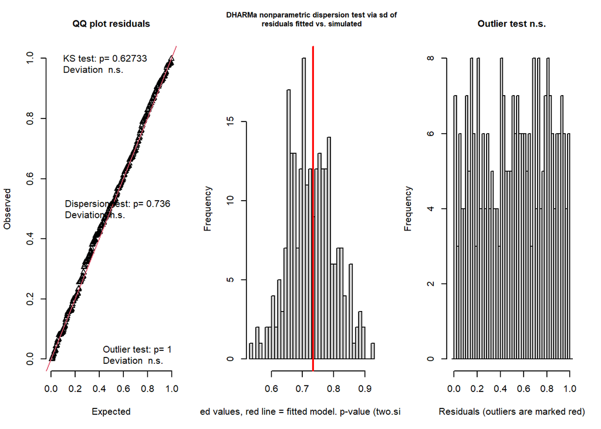

[output not shown]

```r
library(DHARMa)
testResiduals(fit1)
```

**Pseudo R cuadrado**

Aunque los modelos mixtos no generan un valor verdadero de $R^2$, podemos obtener algunas medidas de pseudo $R^2$ para examinar el poder explicativo de los efectos fijos y aleatorios en el modelo. Usemos la función r.squaredGLMM del paquete MuMIn:

```r
library(MuMIn)
r.squaredGLMM(fit1)
```

```
##             R2m R2c
## theoretical  NA  NA
## delta        NA  NA
```

```r
performance::r2_nakagawa(fit1)
```

```
## # R2 for Mixed Models
##
##   Conditional R2: 0.474
##      Marginal R2: 0.367
```

Aquí obtenemos varios valores. Como se indica en el archivo de ayuda, el valor $R^2_m$ es el pseudo $R^2$ marginal, que representa la varianza explicada por los efectos fijos del modelo. Este valor suele ser el que más interesa a los investigadores (qué tan bien las variables predictoras fijas explican lo que ocurre con la variable de respuesta).

El valor $R^2_c$ es el pseudo $R^2$ condicional, y corresponde a la varianza explicada por el modelo completo (los efectos aleatorios y los efectos fijos).

##### Interpretar modelo

```r
summary(fit1)
```

```
##  Family: binomial  ( logit )
## Formula:          present ~ dateS + Year + Habitat + (1 | Site/net)
## Data: birds
##
##       AIC       BIC    logLik -2*log(L)  df.resid
##     287.8     309.6    -137.9     275.8       273
##
## Random effects:
##
## Conditional model:
##  Groups   Name        Variance Std.Dev.
##  net:Site (Intercept) 0.3565   0.5971
##  Site     (Intercept) 0.3095   0.5563
## Number of obs: 279, groups:  net:Site, 30; Site, 3
##
## Conditional model:
##               Estimate Std. Error z value Pr(>|z|)
## (Intercept)     1.1075     0.4629   2.392   0.0167 *
## dateS           0.8334     0.1727   4.826 1.39e-06 ***
## Year2007       -1.3422     0.3291  -4.078 4.53e-05 ***
## HabitatUpland  -2.2559     0.4225  -5.339 9.32e-08 ***
## ---
## Signif. codes:  0 '***' 0.001 '**' 0.01 '*' 0.05 '.' 0.1 ' ' 1
```

##### Graficar modelo

[output not shown]

[output not shown]

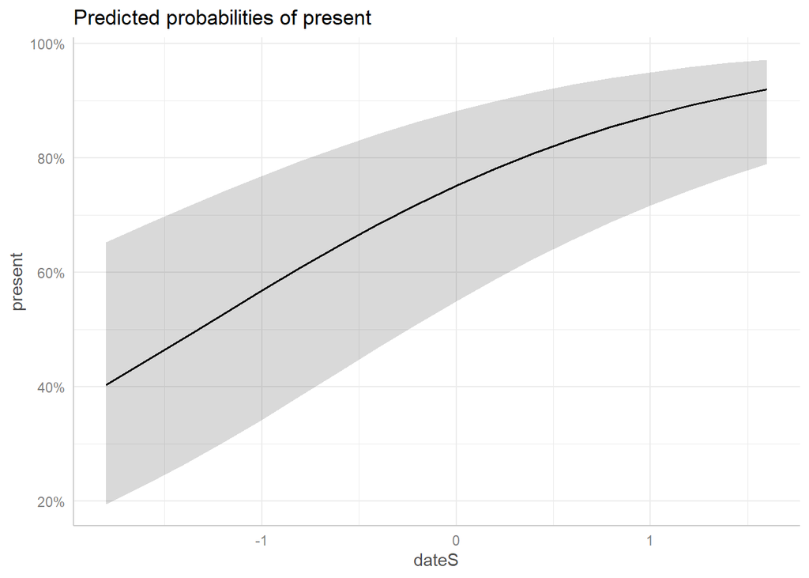

```r
library(ggeffects)

plot(ggpredict(fit1, terms= "dateS"))
```

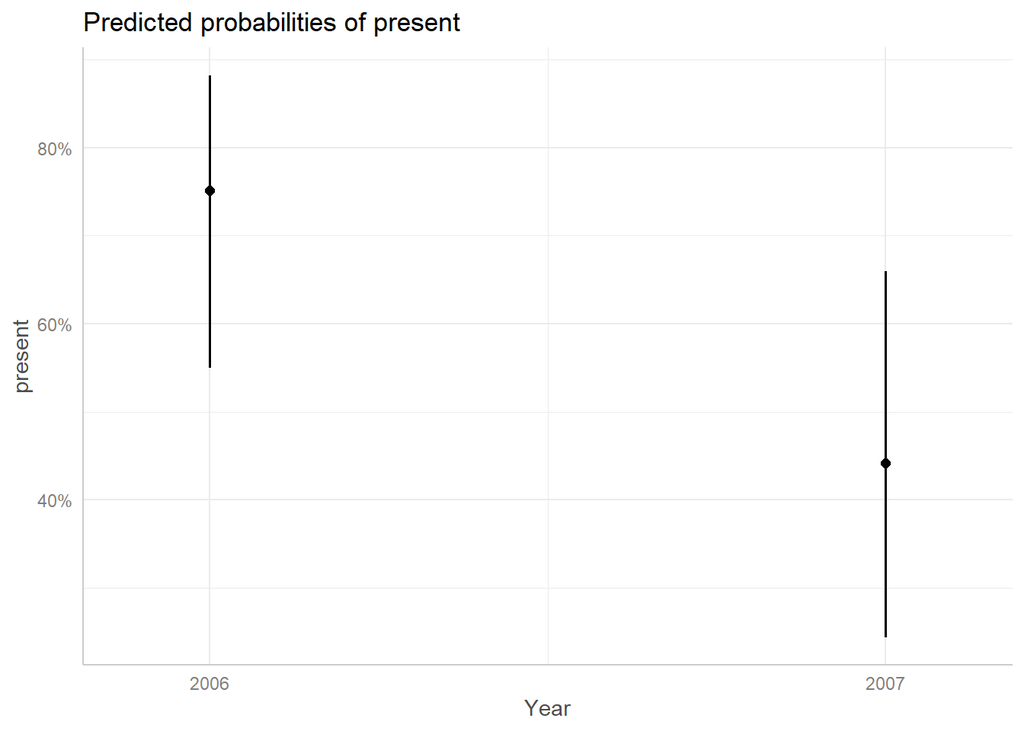

```r
plot(ggpredict(fit1, terms= "Year"))
```

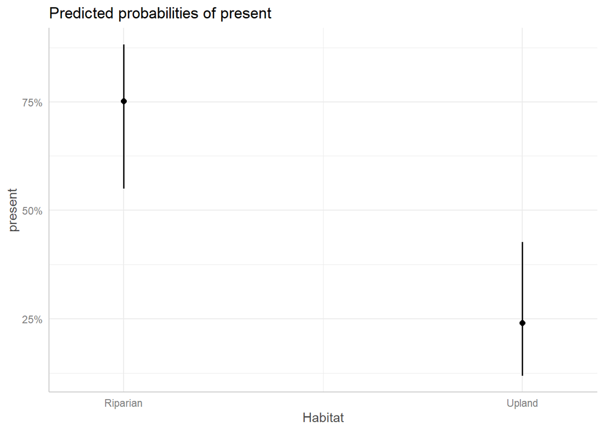

```r
plot(ggpredict(fit1, terms= "Habitat"))
```